# Activity: Steps

### Set up Global Environment

#### 1. loaded dplyr, sqldf, lattice, data.table libraries

#### 2. set echo = TRUE to display code in the HTML file

```r
knitr::opts_chunk$set(echo = TRUE)
library(dplyr)
library(sqldf)
library(lattice)
library(data.table)
```

## Read csv file activity.csv

### The variables included in this dataset are:

#### 1.steps: Number of steps taking in a 5-minute interval (missing values are coded as NA)

#### 2.date: The date on which the measurement was taken in YYYY-MM-DD format

#### 3.interval: Identifier for the 5-minute interval in which measurement was taken

```r
activity<-read.csv("activity.csv")
```

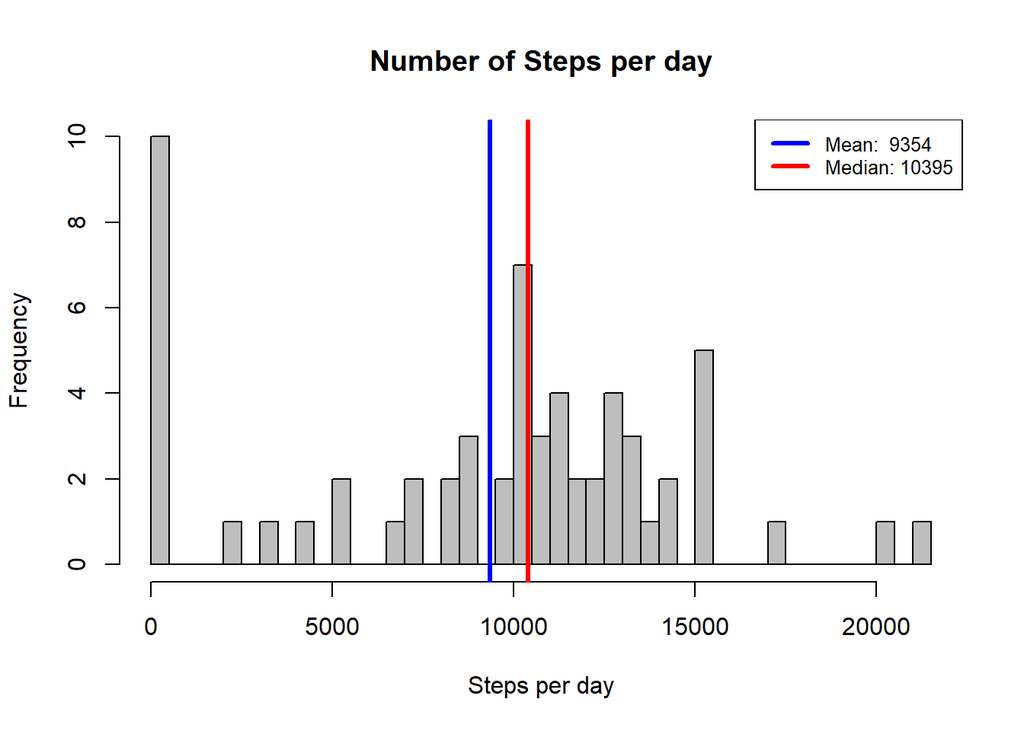

```r
##library(dplyr)
##library(data.table)
activity_tab<-data.table(activity)
steps.day<-activity_tab[, list(steps=sum(steps, na.rm = T)), by = date]
mean_val<-steps.day %>% summarise(mean(steps))
median_val <- steps.day %>% summarise(median(steps))
hist(steps.day$steps, breaks = 60, xlab = "Steps per day", ylab = "Frequency", main = "Number of Steps per day", col = c("grey"))

abline(v=mean_val, lwd = 3, col = 'blue')
abline(v=median_val, lwd = 3, col = 'red')
legend('topright', lty = 1, lwd = 3, col = c("blue", "red"), cex = .8, legend = c(paste('Mean: ', round(mean_val)), paste('Median:', median_val)))
```

```r
##dev.copy(png, filename = "StepsPerDay.png", width = 480, height = 480, units = "px")
##dev.off()
```

#### Plotting a barplot to display Number of steps taken each day

```r
##library(dplyr)
steps.day %>% summarise(mean(steps), median(steps))
```

```
##   mean(steps) median(steps)
## 1     9354.23         10395
```

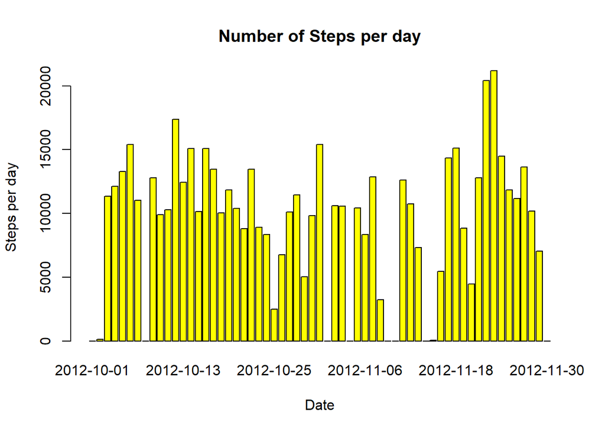

```r
plot<-barplot(height = steps.day$steps, names.arg = steps.day$date,  xlab = "Date", ylab = "Steps per day", col = "yellow", main = "Number of Steps per day")
```

```r
##dev.copy(png, filename = "StepsPerDay_1.png", width = 480, height = 480, units = "px")
##dev.off()
```

## Time series plot of the average number of steps taken

#### 1.Make a time series plot (i.e. type = “l”) of the 5-minute interval (x-axis) and the average number of steps taken, averaged across all days (y-axis)

#### 2.Which 5-minute interval, on average across all the days in the dataset, contains the maximum number of steps?

#### Blue vertical line is for interval with maximum number of steps

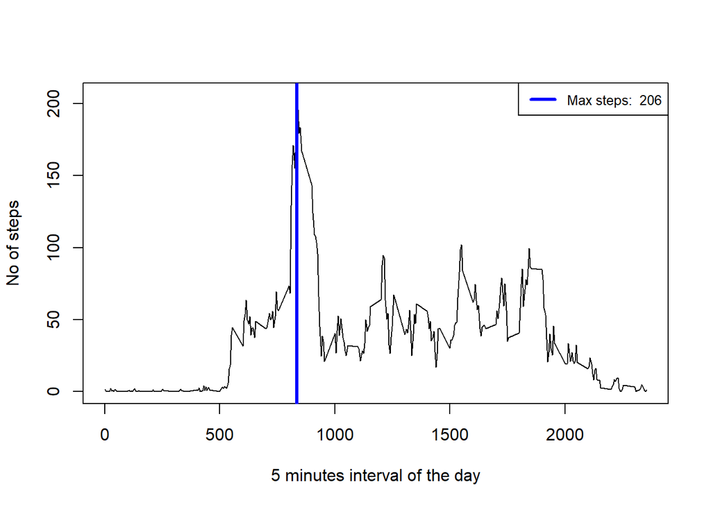

```r
steps.int<-aggregate(steps ~ interval, activity, mean)
 plot( steps.int$interval, steps.int$steps, type = "l", xlab = "5 minutes interval of the day", ylab = "No of steps")
 abline(v=steps.int[which.max(steps.int$steps),1], lwd = 3, col = 'blue')
 legend('topright', lty = 1, lwd = 3, col = c("blue", "red"), cex = .8, legend = c(paste('Max steps: ', round(steps.int[which.max(steps.int$steps), 2]))))
```

```r
## dev.copy(png, filename = "AverageStepsPerInverval.png", width = 480, height = 480, units = "px")
##dev.off()
 print("Interval with maximum number of steps:  ")
```

```
## [1] "Interval with maximum number of steps:  "
```

```r
 print(steps.int[which.max(steps.int$steps), ])
```

```
##     interval    steps
## 104      835 206.1698
```

### Findings of Time Series plot of average steps in 5 minutes interval

#### 1. Maximum number of avaerage steps per interval: 206 in interval 835

## Code to describe and show a strategy for imputing missing data

### Removing NAs from activity dataframe and replacing with interval mean values

#### 1. Create subset of activity data. subset contains only rows with NA in steps field.

#### 2. Replace NA values with interval means

#### 3. create subset of activity data - subset contains only rows with NO NA in steps field

#### 4. merge 2 subsets.

#### 5. Verify:

##### b. Mean and median calculations of merged data and original activity data

##### c. average steps perday of both merged and original data

```r
##library(dplyr)
##library(sqldf)
actNA <- activity[is.na(activity$steps), ]
stepsint <-steps.int
actNA <-sqldf("select * from actNA inner join stepsint on actNA.interval = stepsint.interval ")
actNA <-actNA[, c(5, 2, 3)]
actNA$steps <- round(actNA$steps)
act<-activity[!is.na(activity$steps),]
active <-rbind(act, actNA)
active_tab<-data.table(active)
steps.na<-active_tab[, list(steps=sum(steps, na.rm = T)), by = date]
mean_valna<-steps.na %>% summarise(mean(steps))
median_valna <- steps.na %>% summarise(median(steps))
```

## Histogram of the total number of steps taken each day after missing values are imputed

### Compare Histograms of total number of steps taken each day before and after missing values are imputed

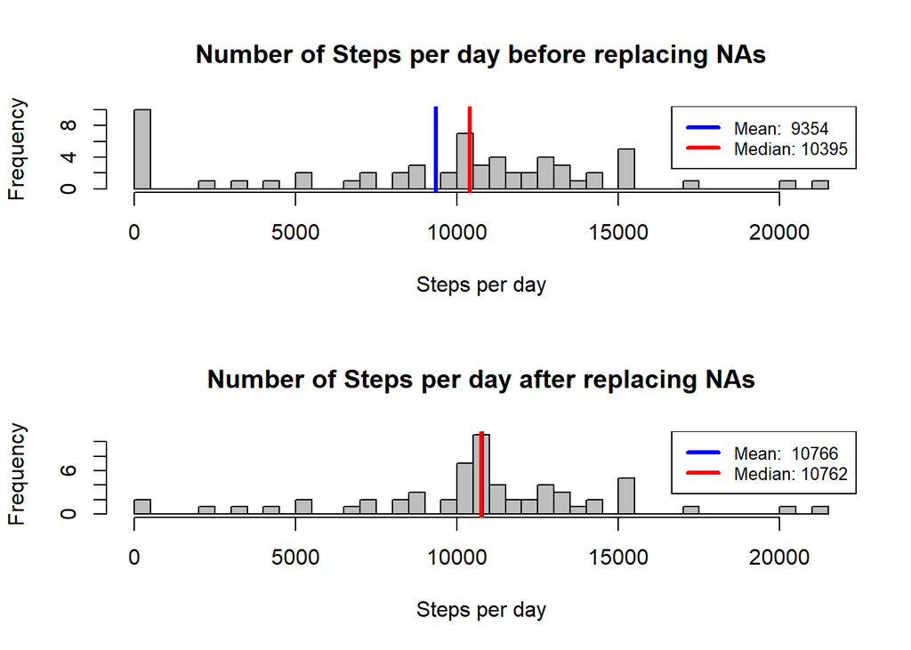

```r
par(mfrow=c(2,1))
hist(steps.day$steps, breaks = 60, xlab = "Steps per day", ylab = "Frequency", main = "Number of Steps per day before replacing NAs", col = c("grey"))

abline(v=mean_val, lwd = 3, col = 'blue')
abline(v=median_val, lwd = 3, col = 'red')
legend('topright', lty = 1, lwd = 3, col = c("blue", "red"), cex = .8, legend = c(paste('Mean: ', round(mean_val)), paste('Median:', median_val)))

hist(steps.na$steps, breaks = 60, xlab = "Steps per day", ylab = "Frequency", main = "Number of Steps per day after replacing NAs", col = c("grey"))
abline(v=mean_valna, lwd = 3, col = 'blue')
abline(v=median_valna, lwd = 3, col = 'red')
legend('topright', lty = 1, lwd = 3, col = c("blue", "red"), cex = .8, legend = c(paste('Mean: ', round(mean_valna)), paste('Median:', median_valna)))
```

```r
##dev.copy(png, filename = "CompareAverageStepsPerInverval.png", width = 480, height = 480, units = "px")
##dev.off()
```

### Findings of comparing between ‘Before Replacing NA’ and ‘after Replacing NAs’

#### 1. Mean Value increased

#### 2. Median Value is not changed much

## ____________________________________________

## Panel plot comparing the average number of steps taken per 5-minute interval across weekdays and weekends

#### 1. Calculate Weekdays of the activity dates

#### 2. Replace Saturday and Sunday with “Weekend” and rest of the days with “Weekdays”

#### 3. Generate Panel plot comparing the average number of steps taken per 5-minute interval across weekdays and weekends

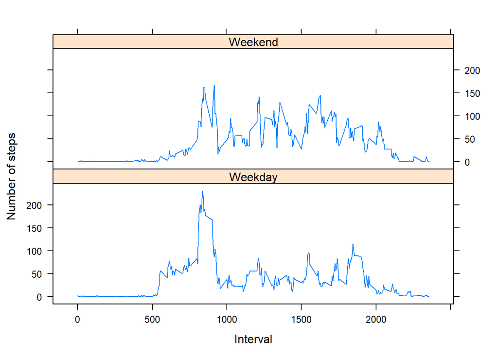

```r
##library(lattice)
active$day<-weekdays(as.Date(active$date,'%Y-%m-%d'))
active$day<-replace(active$day, active$day %in% c("Monday", "Tuesday", "Wednesday", "Thursday", "Friday"), "Weekday")
active$day<-replace(active$day, active$day %in% c("Saturday", "Sunday"), "Weekend")
active.wkday<- aggregate(steps ~ interval + day, active, mean)
xyplot(steps ~ interval | day, active.wkday, type = "l", layout = c(1, 2), xlab = "Interval", ylab = "Number of steps")
```

```r
##dev.copy(png, filename = "AverageStepsPerInverval_Weekday_vs_weekend.png", width = 480, height = 480, units = "px")
##dev.off()
```